# Prediction

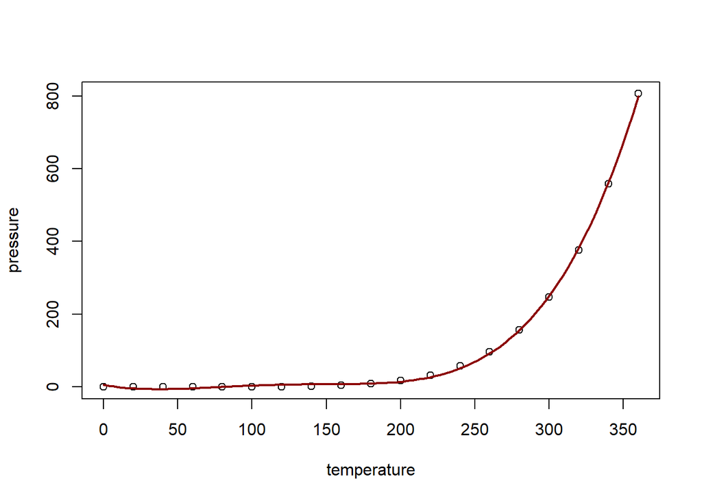

```r
model3 <- lm(pressure ~ temperature +
               I(temperature^2) +
               I(temperature^3) +
               I(temperature^4), data = pressure)
plot(pressure, pch = 21)
coefs <- coef(model3)
curve(coefs[1] + coefs[2] * x + coefs[3] * x^2 + coefs[4] * x^3 + coefs[5] * x^4,
      add = TRUE,
      col = "darkred",
      lwd = 2)
```

In my opinion, 4th level is sufficient, because more steps would not change the fit of the model to the data. We created a good fit.  
Let’s call the `summary()` function on these 3 models to see how coefficient of determination $R^2$ looks.

```r
summary(model1)
```

```
##
## Call:
## lm(formula = pressure ~ temperature + I(temperature^2), data = pressure)
##
## Residuals:
##     Min      1Q  Median      3Q     Max
## -95.142 -54.391  -1.353  48.238 170.374
##
## Coefficients:
##                   Estimate Std. Error t value Pr(>|t|)
## (Intercept)      91.154379  46.262513   1.970 0.066354 .
## temperature      -2.706167   0.595775  -4.542 0.000333 ***
## I(temperature^2)  0.011718   0.001597   7.336 1.67e-06 ***
## ---
## Signif. codes:  0 '***' 0.001 '**' 0.01 '*' 0.05 '.' 0.1 ' ' 1
##
## Residual standard error: 74.42 on 16 degrees of freedom
## Multiple R-squared:  0.9024, Adjusted R-squared:  0.8902
## F-statistic:    74 on 2 and 16 DF,  p-value: 8.209e-09
```

```r
summary(model2)
```

```
##
## Call:
## lm(formula = pressure ~ temperature + I(temperature^2) + I(temperature^3),
##     data = pressure)
##
## Residuals:
##     Min      1Q  Median      3Q     Max
## -32.852 -20.435  -2.487  19.443  46.373
##
## Coefficients:
##                    Estimate Std. Error t value Pr(>|t|)
## (Intercept)      -3.285e+01  1.953e+01  -1.681 0.113373
## temperature       2.086e+00  4.830e-01   4.318 0.000609 ***
## I(temperature^2) -2.247e-02  3.169e-03  -7.093 3.67e-06 ***
## I(temperature^3)  6.332e-05  5.779e-06  10.957 1.48e-08 ***
## ---
## Signif. codes:  0 '***' 0.001 '**' 0.01 '*' 0.05 '.' 0.1 ' ' 1
##
## Residual standard error: 25.61 on 15 degrees of freedom
## Multiple R-squared:  0.9892, Adjusted R-squared:  0.987
## F-statistic: 456.4 on 3 and 15 DF,  p-value: 5.889e-15
```

```r
summary(model3)
```

```
##
## Call:
## lm(formula = pressure ~ temperature + I(temperature^2) + I(temperature^3) +
##     I(temperature^4), data = pressure)
##
## Residuals:
##     Min      1Q  Median      3Q     Max
## -7.1989 -4.2112  0.2224  4.0172  7.0729
##
## Coefficients:
##                    Estimate Std. Error t value Pr(>|t|)
## (Intercept)       6.453e+00  4.645e+00   1.389 0.186418
## temperature      -7.992e-01  1.893e-01  -4.223 0.000852 ***
## I(temperature^2)  1.588e-02  2.226e-03   7.135 5.06e-06 ***
## I(temperature^3) -1.052e-04  9.415e-06 -11.179 2.31e-08 ***
## I(temperature^4)  2.341e-07  1.297e-08  18.056 4.28e-11 ***
## ---
## Signif. codes:  0 '***' 0.001 '**' 0.01 '*' 0.05 '.' 0.1 ' ' 1
##
## Residual standard error: 5.38 on 14 degrees of freedom
## Multiple R-squared:  0.9996, Adjusted R-squared:  0.9994
## F-statistic:  7841 on 4 and 14 DF,  p-value: < 2.2e-16
```

We see that in `model3` coefficient of determination $R^2$ is the highest.  
We created a good model with a good fit to the data.  
Now, we predict the pressure value for a temperature equal to 400.

```r
predict(model3, list(temperature = 400))
```

```
##        1
## 1485.504
```

## Multiple Regression

Previously, we assumed that the dependent variable depends on only one variable. Sometimes phenomenon under study depends not only on one factor, but on many. This situation happens in multiple regression. A good method for building a multiple regression model is stepwise regression. Suppose we create a model containing all the variables. Using stepwise regression, we can remove a variable at each step to get the best model. The quality of the model is measured by Akaike’s Information Criterion (AIC) or Bayesian Information Criterion (BIC). We care about prediction quality, so we should use the AIC criterion. The smaller AIC value, the better the model. Let’s see a multiple regression with an example.

### Example: Longley’s Economic Regression Data

Dataset `longley` contains 7 economical variables, observed yearly from 1947 to 1962. If we want to learn more about this dataset, just use the command:

```r
?longley
```

We decide to model the `Employed` variable. The notation `Employed ~ .` means that the independent variables are the other variables in the dataset.

```r
model1 <- lm(Employed ~ ., data = longley)
```

We will try to create the best model using two methods. Without and with stepwise regression.

#### Method 1 - without stepwise regression

We use `summary()` function on `model1`. We see the coefficients for each independent variable of the model.

```r
summary(model1)
```

```
##
## Call:
## lm(formula = Employed ~ ., data = longley)
##
## Residuals:
##      Min       1Q   Median       3Q      Max
## -0.41011 -0.15767 -0.02816  0.10155  0.45539
##
## Coefficients:
##                Estimate Std. Error t value Pr(>|t|)
## (Intercept)  -3.482e+03  8.904e+02  -3.911 0.003560 **
## GNP.deflator  1.506e-02  8.492e-02   0.177 0.863141
## GNP          -3.582e-02  3.349e-02  -1.070 0.312681
## Unemployed   -2.020e-02  4.884e-03  -4.136 0.002535 **
## Armed.Forces -1.033e-02  2.143e-03  -4.822 0.000944 ***
## Population   -5.110e-02  2.261e-01  -0.226 0.826212
## Year          1.829e+00  4.555e-01   4.016 0.003037 **
## ---
## Signif. codes:  0 '***' 0.001 '**' 0.01 '*' 0.05 '.' 0.1 ' ' 1
##
## Residual standard error: 0.3049 on 9 degrees of freedom
## Multiple R-squared:  0.9955, Adjusted R-squared:  0.9925
## F-statistic: 330.3 on 6 and 9 DF,  p-value: 4.984e-10
```

`Summary()` function showed us which variables are significant and which are not. We remove variables that are not significant (`GNP.deflator`, `GNP` and `Population`) from the model.

```r
model2 <- update(model1, . ~ . -GNP.deflator -GNP -Population)
summary(model2)
```

```
##
## Call:
## lm(formula = Employed ~ Unemployed + Armed.Forces + Year, data = longley)
##
## Residuals:
##      Min       1Q   Median       3Q      Max
## -0.57285 -0.11989  0.04087  0.13979  0.75303
##
## Coefficients:
##                Estimate Std. Error t value Pr(>|t|)
## (Intercept)  -1.797e+03  6.864e+01 -26.183 5.89e-12 ***
## Unemployed   -1.470e-02  1.671e-03  -8.793 1.41e-06 ***
## Armed.Forces -7.723e-03  1.837e-03  -4.204  0.00122 **
## Year          9.564e-01  3.553e-02  26.921 4.24e-12 ***
## ---
## Signif. codes:  0 '***' 0.001 '**' 0.01 '*' 0.05 '.' 0.1 ' ' 1
##
## Residual standard error: 0.3321 on 12 degrees of freedom
## Multiple R-squared:  0.9928, Adjusted R-squared:  0.9911
## F-statistic: 555.2 on 3 and 12 DF,  p-value: 3.916e-13
```

Comparing the `Adjusted R-squared` coefficients of both model, we notice that `model1` is better than `model2`, but it does not mean that we have chosen the best model because we did the variable removal manually. Now, let’s try stepwise regression.

#### Method 2 - with stepwise regression

`Model1` looks the same as before. `Step()` function shows us at each step which variables it removes from the model and finally displays the best model selected using AIC criterion.

```r
print(model3 <- step(model1))
```

```
## Start:  AIC=-33.22
## Employed ~ GNP.deflator + GNP + Unemployed + Armed.Forces + Population +
##     Year
##
##                Df Sum of Sq     RSS     AIC
## - GNP.deflator  1   0.00292 0.83935 -35.163
## - Population    1   0.00475 0.84117 -35.129
## - GNP           1   0.10631 0.94273 -33.305
## <none>                      0.83642 -33.219
## - Year          1   1.49881 2.33524 -18.792
## - Unemployed    1   1.59014 2.42656 -18.178
## - Armed.Forces  1   2.16091 2.99733 -14.798
##
## Step:  AIC=-35.16
## Employed ~ GNP + Unemployed + Armed.Forces + Population + Year
##
##                Df Sum of Sq    RSS     AIC
## - Population    1   0.01933 0.8587 -36.799
## <none>                      0.8393 -35.163
## - GNP           1   0.14637 0.9857 -34.592
## - Year          1   1.52725 2.3666 -20.578
## - Unemployed    1   2.18989 3.0292 -16.628
## - Armed.Forces  1   2.39752 3.2369 -15.568
##
## Step:  AIC=-36.8
## Employed ~ GNP + Unemployed + Armed.Forces + Year
##
##                Df Sum of Sq    RSS     AIC
## <none>                      0.8587 -36.799
## - GNP           1    0.4647 1.3234 -31.879
## - Year          1    1.8980 2.7567 -20.137
## - Armed.Forces  1    2.3806 3.2393 -17.556
## - Unemployed    1    4.0491 4.9077 -10.908
##
## Call:
## lm(formula = Employed ~ GNP + Unemployed + Armed.Forces + Year,
##     data = longley)
##
## Coefficients:
##  (Intercept)           GNP    Unemployed  Armed.Forces          Year
##   -3.599e+03    -4.019e-02    -2.088e-02    -1.015e-02     1.887e+00
```

We have selected the best multiple regression model (`model3`). We will now create a prediction for the number of people employed (`Employed`) using `predict()` function.

```r
newdata = data.frame(Year = 1970,
                     GNP = 600,
                     Unemployed = 500,
                     Armed.Forces = 300)
predict(model3, newdata)
```

```
##        1
## 81.86721
```

## Logistic Regression

Logistic regression is a special and important example of a generalized linear model. We assume that the dependent variable $Y$ takes only two values (most often $Y$ is a binary variable). For example, the values of the $Y$ variable will be: good or bad, 1 or 0, healthy or sick.

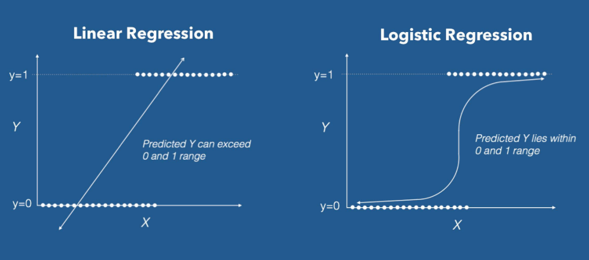

### Example: Fair’s Extramarital Affairs Data

Dataset is infidelity data, known as Fair’s Affairs. This data contains 9 variables which hold information such as how often respondents have affairs during the past years, as well as their age, gender, education, years, married etc.

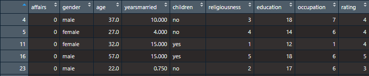

Applying logistic regression, we can find which factors contributed the most to infidelity.  
We upload our data. Dataset `Affairs` comes from `AER` package.

```r
# if library() function doesn't work type install.packages("AER")
library(AER)
data(Affairs)
```

We are interested in the binary outcome for our response variable (had an affair/did not have an affair). We create a new binary column (`ynaffairs`) which will be our dependent variable (1 means “Yes, had an affair”, 0 means “No, did not have an affair”).

```r
library(dplyr)
Affairs <- Affairs %>%
  mutate(ynaffairs = ifelse(affairs > 0, 1, 0))
```

In the next step, we create a logistic model and see the statistics of model using the `summary()` function.

```r
model_glm <- glm(ynaffairs ~ gender + age +
                   yearsmarried + children +
                   religiousness + education +
                   occupation + rating,
                 data = Affairs,
                 family = 'binomial')
summary(model_glm)
```

```
##
## Call:
## glm(formula = ynaffairs ~ gender + age + yearsmarried + children +
##     religiousness + education + occupation + rating, family = "binomial",
##     data = Affairs)
##
## Deviance Residuals:
##     Min       1Q   Median       3Q      Max
## -1.5713  -0.7499  -0.5690  -0.2539   2.5191
##
## Coefficients:
##               Estimate Std. Error z value Pr(>|z|)
## (Intercept)    1.37726    0.88776   1.551 0.120807
## gendermale     0.28029    0.23909   1.172 0.241083
## age           -0.04426    0.01825  -2.425 0.015301 *
## yearsmarried   0.09477    0.03221   2.942 0.003262 **
## childrenyes    0.39767    0.29151   1.364 0.172508
## religiousness -0.32472    0.08975  -3.618 0.000297 ***
## education      0.02105    0.05051   0.417 0.676851
## occupation     0.03092    0.07178   0.431 0.666630
## rating        -0.46845    0.09091  -5.153 2.56e-07 ***
## ---
## Signif. codes:  0 '***' 0.001 '**' 0.01 '*' 0.05 '.' 0.1 ' ' 1
##
## (Dispersion parameter for binomial family taken to be 1)
##
##     Null deviance: 675.38  on 600  degrees of freedom
## Residual deviance: 609.51  on 592  degrees of freedom
## AIC: 627.51
##
## Number of Fisher Scoring iterations: 4
```

We choose the best model using `step()` function.

```r
model_glm2 <- step(model_glm)
```

```
## Start:  AIC=627.51
## ynaffairs ~ gender + age + yearsmarried + children + religiousness +
##     education + occupation + rating
##
##                 Df Deviance    AIC
## - education      1   609.68 625.68
## - occupation     1   609.70 625.70
## - gender         1   610.89 626.89
## - children       1   611.40 627.40
## <none>               609.51 627.51
## - age            1   615.67 631.67
## - yearsmarried   1   618.34 634.34
## - religiousness  1   622.92 638.92
## - rating         1   636.75 652.75
##
## Step:  AIC=625.68
## ynaffairs ~ gender + age + yearsmarried + children + religiousness +
##     occupation + rating
##
##                 Df Deviance    AIC
## - occupation     1   610.15 624.15
## - gender         1   611.29 625.29
## - children       1   611.62 625.62
## <none>               609.68 625.68
## - age            1   615.78 629.78
## - yearsmarried   1   618.46 632.46
## - religiousness  1   623.27 637.27
## - rating         1   636.93 650.93
##
## Step:  AIC=624.15
## ynaffairs ~ gender + age + yearsmarried + children + religiousness +
##     rating
##
##                 Df Deviance    AIC
## - children       1   611.86 623.86
## <none>               610.15 624.15
## - gender         1   613.41 625.41
## - age            1   616.00 628.00
## - yearsmarried   1   619.07 631.07
## - religiousness  1   623.98 635.98
## - rating         1   637.23 649.23
##
## Step:  AIC=623.86
## ynaffairs ~ gender + age + yearsmarried + religiousness + rating
##
##                 Df Deviance    AIC
## <none>               611.86 623.86
## - gender         1   615.36 625.36
## - age            1   618.05 628.05
## - religiousness  1   625.57 635.57
## - yearsmarried   1   626.23 636.23
## - rating         1   639.93 649.93
```

```r
summary(model_glm2)
```

```
##
## Call:
## glm(formula = ynaffairs ~ gender + age + yearsmarried + religiousness +
##     rating, family = "binomial", data = Affairs)
##
## Deviance Residuals:
##     Min       1Q   Median       3Q      Max
## -1.5623  -0.7495  -0.5664  -0.2671   2.3975
##
## Coefficients:
##               Estimate Std. Error z value Pr(>|z|)
## (Intercept)    1.94760    0.61234   3.181 0.001470 **
## gendermale     0.38612    0.20703   1.865 0.062171 .
## age           -0.04393    0.01806  -2.432 0.015011 *
## yearsmarried   0.11133    0.02983   3.732 0.000190 ***
## religiousness -0.32714    0.08947  -3.656 0.000256 ***
## rating        -0.46721    0.08928  -5.233 1.67e-07 ***
## ---
## Signif. codes:  0 '***' 0.001 '**' 0.01 '*' 0.05 '.' 0.1 ' ' 1
##
## (Dispersion parameter for binomial family taken to be 1)
##
##     Null deviance: 675.38  on 600  degrees of freedom
## Residual deviance: 611.86  on 595  degrees of freedom
## AIC: 623.86
##
## Number of Fisher Scoring iterations: 4
```

Let’s try to make a prediction. As before, we create new data containing the values of predictor variables we’re interested in. We apply the prediction function to get the probabilities of having affair for these new respondents.  
We notice that change of having affair declining from 0.68 the marriage is rated 1 = “very unhappy” to 0.25 when the marriage is rated 5 = “very happy”. It indicates the unhappy couple are three times more likely to have an affair compared to the happy one.  
We include the argument `type = "response"` (in `predict()` function) in order to get predicted probability that y = 1.

```r
newdata <- data.frame(rating = c(1, 2, 3, 4, 5),
                      age = 25,
                      yearsmarried = 3,
                      religiousness = 1,
                      gender = "male")
predict(model_glm2,
        newdata = newdata,
        type = "response")
```

```
##         1         2         3         4         5
## 0.6846482 0.5763982 0.4602822 0.3483231 0.2509354
```

We could change the new data a bit and see how the probability of having affair changes with age. Let’s create a new data.  
We notice that the older a person gets, the probability of having affair decreases.

```r
newdata <- data.frame(rating = 5,
                      age = c(25, 35, 45, 55, 65),
                      yearsmarried = 3,
                      religiousness = 1,
                      gender = "female")
predict(model_glm2,
        newdata = newdata,
        type = "response")
```

```
##          1          2          3          4          5
## 0.18546489 0.12797240 0.08641139 0.05745859 0.03780521
```

## Exercises

1. Dataset `cars` contains two columns: speed (`speed`) and stopping distance (`dist`).
- draw a plot to see how the data looks
- create a linear regression model and add regression line to plot
- create a quadratic regression model and add regression line to plot
- consider which model is better and predict `dist` value, when `speed` is 40.
2. Using dataset `Boston` from `MASS` package, fit a polynomial regression model.
- draw a plot to see how the data looks (choose x value as `medv` and y as `lstat`)
- create a polynomial regression models (`lstat` is dependent variable and `medv` is independent variable) with different levels of the polynomial. In your opinion, which is the best? (use measures from lecture)
- using the best polynomial regression model, predict `lstat` value where `medv` = 50.04
3. Use dataset `marketing` from `datarium` package. Read more information about this dataset (`?marketing`). Create multiple regression model using method 1 or method 2 from the lecture. Predict `sales` value for your selected variable values.
4. Let’s more predict. In chapter Logistic Regression is example: Fair’s Extramarital Affairs Data. Take the best chosen model and predict the probabilities of having affair for these new data:
- `rating` is 3, `age` is 20, `yearsmarried` is 2, `gender` is male and `religiousness` is 1
- `rating` is 5, `age` is 80, `yearsmarried` is 10 or 20, `gender` is female, religiousness` is 3

## References

1 T. Górecki, “Data analysis” - lectures, Adam Mickiewicz University in Poznań, Poznań 2021.  
2. Simon Jackman (2020). pscl: Classes and Methods for R Developed in the Political Science Computational Laboratory. United States Studies Centre, University of Sydney. Sydney, New South Wales, Australia. R package version 1.5.5. URL https://github.com/atahk/pscl/.  
3. Gareth James, Daniela Witten, Trevor Hastie, Robert Tibshirani, “An Introduction to Statistical Learning with Applications in R”, Springer Science+Business Media, New York 2013.  
4. Christian Kleiber and Achim Zeileis (2008). Applied Econometrics with R. New York: Springer-Verlag. ISBN 978-0-387-77316-2. URL https://CRAN.R-project.org/package=AER.  
5. Norman Matloff, “Statistical Regression and Classification From Linear Models to Machine Learning”, CRC Press, 2017 by Taylor & Francis Group.  
6. Michaelino Mervisiano’s article, https://towardsdatascience.com/how-to-do-logistic-regression-in-r-456e9cfec7cd.  
7. P. Piasecki, “Data analysis” - classes, Adam Mickiewicz University in Poznań, Poznań 2021.  
8. Hadley Wickham, Romain François, Lionel Henry and Kirill Müller (2021). dplyr: A Grammar of Data Manipulation. R package version 1.0.7. https://CRAN.R-project.org/package=dplyr.